# Forest_fires_report

Nate Sheibley

2024-04-11

# Portugal Forest Fire Factors

Forest fire data from Portugal will explored to identify which forest fire factors correlate to frequency and severity of forest fires.

Data can be found [here](https://dsserver-prod-resources-1.s3.amazonaws.com/277/forestfires.csv)

This data is associated with fosrest fire prediction modelling in Portugal from [this](http://www3.dsi.uminho.pt/pcortez/fires.pdf) paper.

## Packages to be used

A subset of tidyverse packages.

All code is displayed, in a normal report, liberal use of echo=FALSE would be used to hide visualization code.

```r
packages <- c('yaml',
              'readr',
              'tidyr',
              'dplyr',
              'tibble',
              'stringr',
              'lubridate',
              'knitr',
              'ggplot2')
lapply(packages, library, character.only=TRUE)
```

### Initial exploration

517 rows with 13 columns.

13 columns correspond to conditions and fire statistics.

Zero NA values.

```r
forest_tib <- read_csv('forestfires.csv')
glimpse(forest_tib)
```

```
## Rows: 517
## Columns: 13
## $ X     <dbl> 7, 7, 7, 8, 8, 8, 8, 8, 8, 7, 7, 7, 6, 6, 6, 6, 5, 8, 6, 6, 6, 5…
## $ Y     <dbl> 5, 4, 4, 6, 6, 6, 6, 6, 6, 5, 5, 5, 5, 5, 5, 5, 5, 5, 4, 4, 4, 4…
## $ month <chr> "mar", "oct", "oct", "mar", "mar", "aug", "aug", "aug", "sep", "…
## $ day   <chr> "fri", "tue", "sat", "fri", "sun", "sun", "mon", "mon", "tue", "…
## $ FFMC  <dbl> 86.2, 90.6, 90.6, 91.7, 89.3, 92.3, 92.3, 91.5, 91.0, 92.5, 92.5…
## $ DMC   <dbl> 26.2, 35.4, 43.7, 33.3, 51.3, 85.3, 88.9, 145.4, 129.5, 88.0, 88…
## $ DC    <dbl> 94.3, 669.1, 686.9, 77.5, 102.2, 488.0, 495.6, 608.2, 692.6, 698…
## $ ISI   <dbl> 5.1, 6.7, 6.7, 9.0, 9.6, 14.7, 8.5, 10.7, 7.0, 7.1, 7.1, 22.6, 0…
## $ temp  <dbl> 8.2, 18.0, 14.6, 8.3, 11.4, 22.2, 24.1, 8.0, 13.1, 22.8, 17.8, 1…
## $ RH    <dbl> 51, 33, 33, 97, 99, 29, 27, 86, 63, 40, 51, 38, 72, 42, 21, 44, …
## $ wind  <dbl> 6.7, 0.9, 1.3, 4.0, 1.8, 5.4, 3.1, 2.2, 5.4, 4.0, 7.2, 4.0, 6.7,…
## $ rain  <dbl> 0.0, 0.0, 0.0, 0.2, 0.0, 0.0, 0.0, 0.0, 0.0, 0.0, 0.0, 0.0, 0.0,…
## $ area  <dbl> 0, 0, 0, 0, 0, 0, 0, 0, 0, 0, 0, 0, 0, 0, 0, 0, 0, 0, 0, 0, 0, 0…
```

```r
sum(is.na(forest_tib))
```

```
## [1] 0
```

## Cleaning the data

### Cleaning and factoring dates

The date data is the only data needing cleaning

There are zero NA values in the dataset.

Zero area burned will be addressed in the analysis

```r
# convert month string abbreviation to ordered month factor
# label according to month.name
# mutate to factor in order to save memory and increase speed
month_abbr <- tolower(month.abb)
forest_tib <- forest_tib %>%
  mutate(month = factor(month,levels=month_abbr, ordered = T))
levels(forest_tib$month) <- month.name
#convert day of week to ordered factor
day_abbr = c('mon', 'tue', 'wed', 'thu', 'fri', 'sat', 'sun')
day_names <- c("Monday","Tuesday","Wednesday","Thursday","Friday","Saturday","Sunday")
forest_tib <- forest_tib %>%
  mutate(day = factor(day,levels=day_abbr, ordered = T)) %>%
  select(-c('X', 'Y'))
levels(forest_tib$day) <- day_names
```

## Aggregating fire data by month-date

Forest fires occur moderately more frequently near weekends (Friday through Sunday) rather than midweek (Monday through Thursday).

This may indicate human causes may have an impact on the number of forest fires

The vast majority of fires occur in August and September. This is the dry season at the end of summer in the northern hemisphere.

There is also a small peak in March, which is interesting.

```r
fires_by_month <- forest_tib %>%
  group_by(month) %>%
  summarise(num_fires=n())
fires_by_day <- forest_tib %>%
  group_by(day) %>%
  summarise(num_fires=n())
```

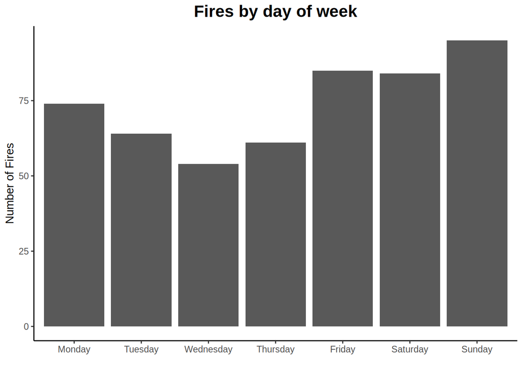

```r
classic_an <- theme_classic() + theme(plot.title = element_text(hjust = 0.5, face = 'bold', size = 16))
theme_set(classic_an)

fires_by_day %>%
  ggplot(aes(x=day, y=num_fires)) +
  geom_col() +
  labs(title='Fires by day of week', y='Number of Fires',x='')
```

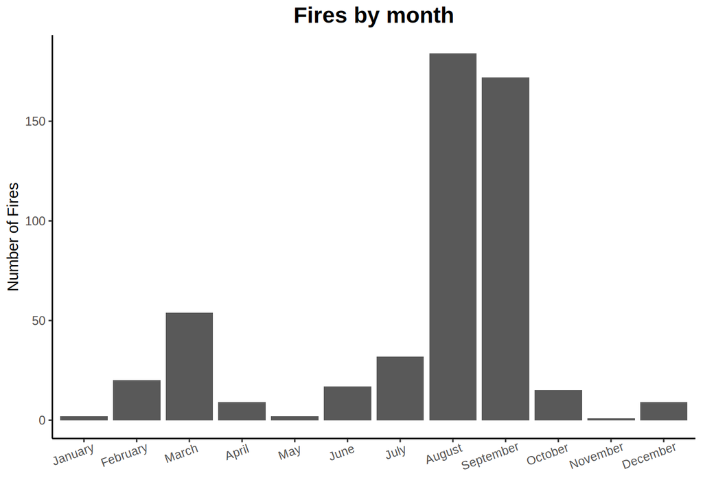

```r
forest_tib %>%
  ggplot(aes(x=month)) +
  geom_bar() +
  labs(title='Fires by month', y='Number of Fires', x='') +
  theme(axis.text.x = element_text(angle=20,hjust=0.8))
```

## Fire Factors in August and September

There are clear increases in Duff Moisture Code index (DMC), and temperature (temp) preceding and overlapping September and August.

Interestingly August had higher rainfall than average, so there could be a connection between new growth and fire season, or thunderstorms.

The Fine Fuel Moisture Code index (FFMC) and Initial Spread Index (ISI) are high for the entire summer preceding the increased fire likelyhood.

ISI and wind correlate to the increase in number of fires in March, along with an initial rise in temperature at the start of spring.

## Fire Factors in March

The Fine Fuel Moisture Code index (FFMC) initially rises and stabilizes in march, from the lower winter values. Springtime also results in the first of two increases in Initial Spread Index (ISI) and Duff moisture code (DMC), and a local minima in relative humidity (RH).

```r
fire_factor__freq_relations <- forest_tib %>%
  pivot_longer(cols=-c(month, day),
               names_to = 'fire_factors',
               values_to = 'values') %>%
  group_by(month, fire_factors) %>%
  summarize(avg = mean(values))
```

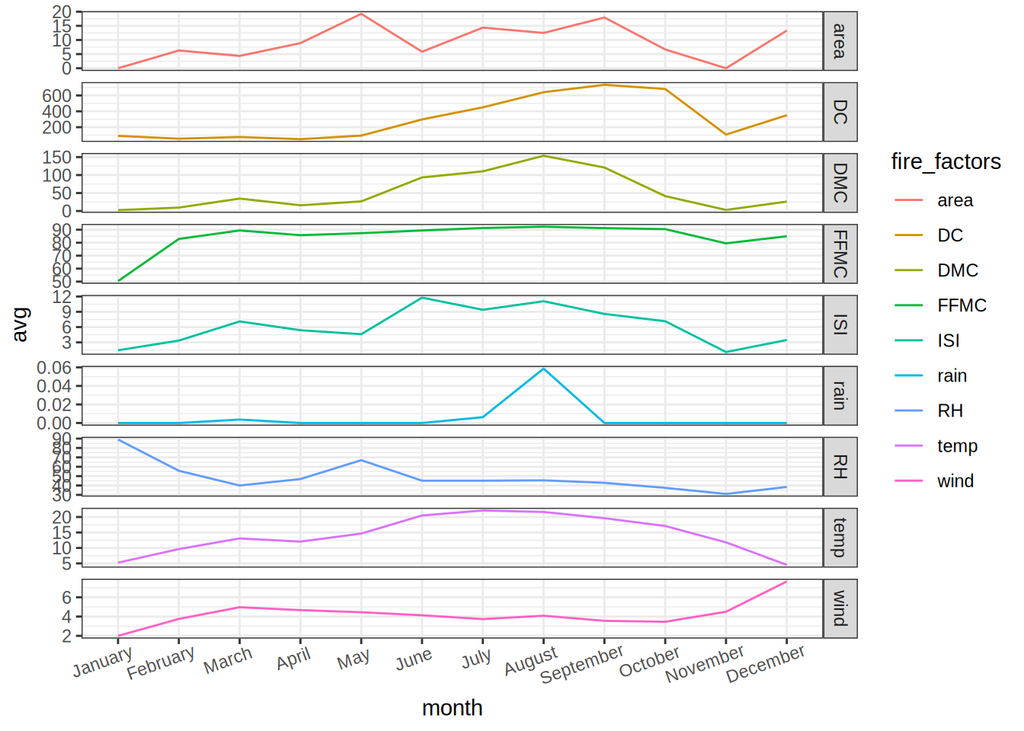

```r
fire_factor__freq_relations %>%
  ggplot(aes(x=month, y=avg,
             color = fire_factors,
             group = fire_factors)) +
  geom_line()+
  facet_grid(rows=vars(fire_factors), scale='free_y') +
  theme_bw() +
  theme(axis.text.x = element_text(angle=20,hjust=0.8))
```

## Using area as a proxy for severity

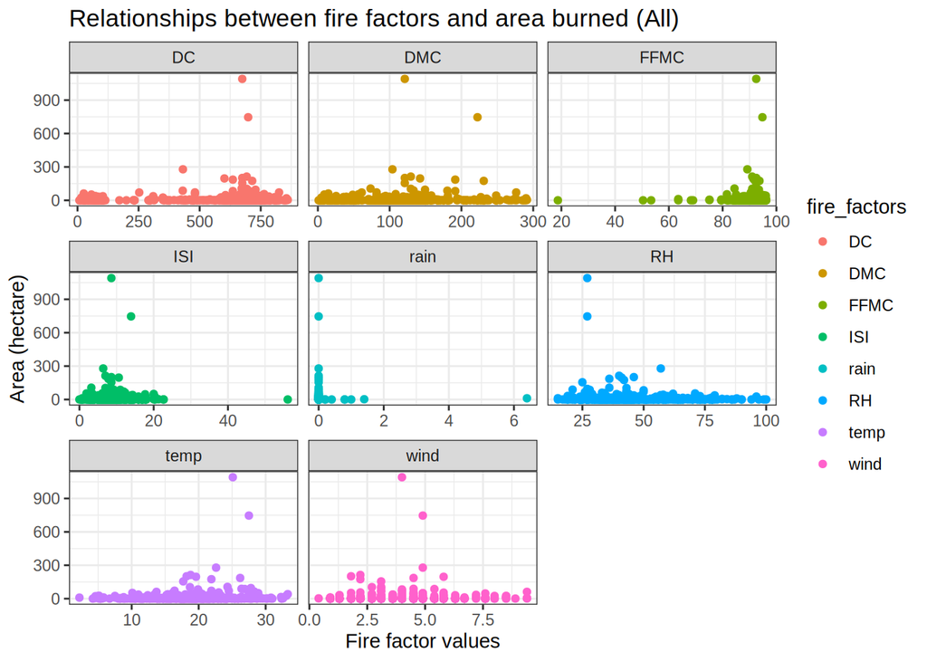

```r
fire_factor_area_relations <- forest_tib %>%
  pivot_longer(cols=-c(month, day, area),
               names_to = 'fire_factors',
               values_to = 'values')

fire_factor_area_relations %>%
  ggplot(aes(y=area, x=values, color = fire_factors)) +
  geom_point()+
  facet_wrap(facets=vars(fire_factors), scales='free_x') +
  theme_bw() +
  labs(title = 'Relationships between fire factors and area burned (All)',
       x = 'Fire factor values',
       y = 'Area (hectare)')
```

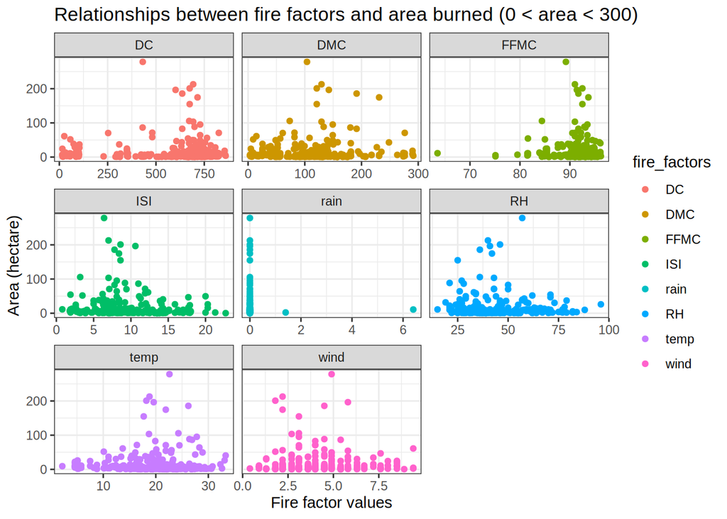

```r
fire_factor_area_relations %>% filter(area<  300 & area > 0) %>%
  ggplot(aes(y=area, x=values, color = fire_factors)) +
  geom_point()+
  facet_wrap(facets = vars(fire_factors), scales ='free_x') +
  theme_bw() +
  labs(title = 'Relationships between fire factors and area burned (0 < area < 300)',
       x = 'Fire factor values',
       y = 'Area (hectare)')
```

Raw data variables, as documented in the paper:

```
X: X-axis spatial coordinate within the Montesinho park map: 1 to 9
Y: Y-axis spatial coordinate within the Montesinho park map: 2 to 9
month: Month of the year: 'jan' to 'dec'
day: Day of the week: 'mon' to 'sun'
FFMC: Fine Fuel Moisture Code index from the FWI system: 18.7 to 96.20
DMC: Duff Moisture Code index from the FWI system: 1.1 to 291.3
DC: Drought Code index from the FWI system: 7.9 to 860.6
ISI: Initial Spread Index from the FWI system: 0.0 to 56.10
temp: Temperature in Celsius degrees: 2.2 to 33.30
RH: Relative humidity in percentage: 15.0 to 100
wind: Wind speed in km/h: 0.40 to 9.40
rain: Outside rain in mm/m2 : 0.0 to 6.4
area: The burned area of the forest (in ha): 0.00 to 1090.84
```